# Describing Data

Session 1

Luis F. Gómez L.

luis.gomezl@unimilitar.edu.co

Distance Learning Faculty

14 September, 2026

# Please Read Me

- This presentation is based on (Chapman & Feit, 2019, Chapter 3)
- **Purpose**
  - Utilize descriptive statistics and single variable visualization techniques for summarizing and exploring a data set.

# Weekly store data

- **storeNum**: store identifier
- **Year**: year identifier
- **Week**: week as it would appear in the ISO 8601 system (1-52)
- **p1sales**: units sold of product 1
- **p2sales**: units sold of product 2
- **p1price**: price of product 1
- **p2price**: price of product 2
- **p1prom**: whether product 1 was promoted (1) or not (0)
- **p2prom**: whether product 2 was promoted (1) or not (0)
- **country**: two-letter country codes defined in ISO 3166-1

```r
weekly_store <- read_csv(
  file = "http://goo.gl/QPDdMl"
)

weekly_store |> head(n = 5)
```

```
# A tibble: 5 × 10
  storeNum  Year  Week p1sales p2sales p1price p2price p1prom p2prom country
     <dbl> <dbl> <dbl>   <dbl>   <dbl>   <dbl>   <dbl>  <dbl>  <dbl> <chr>
1      101     1     1     127     106    2.29    2.29      0      0 US
2      101     1     2     137     105    2.49    2.49      0      0 US
3      101     1     3     156      97    2.99    2.99      1      0 US
4      101     1     4     117     106    2.99    3.19      0      0 US
5      101     1     5     138     100    2.49    2.59      0      1 US
```

- **Import data**

```r
weekly_store <- weekly_store |>
  mutate(
    storeNum = factor(storeNum, ordered = FALSE),
    Year = factor(Year, levels = 1:2, ordered = TRUE),
    Week = factor(Week, levels = 1:52, ordered = TRUE),
    p1prom = as.logical(p1prom),
    p2prom = as.logical(p2prom)
  )

weekly_store |> head(n = 5)
```

```
# A tibble: 5 × 10
  storeNum Year  Week  p1sales p2sales p1price p2price p1prom p2prom country
  <fct>    <ord> <ord>   <dbl>   <dbl>   <dbl>   <dbl> <lgl>  <lgl>  <chr>
1 101      1     1         127     106    2.29    2.29 FALSE  FALSE  US
2 101      1     2         137     105    2.49    2.49 FALSE  FALSE  US
3 101      1     3         156      97    2.99    2.99 TRUE   FALSE  US
4 101      1     4         117     106    2.99    3.19 FALSE  FALSE  US
5 101      1     5         138     100    2.49    2.59 FALSE  TRUE   US
```

- **Transform data**

```r
weekly_store |>
  glimpse()
```

```
Rows: 2,080
Columns: 10
$ storeNum <fct> 101, 101, 101, 101, 101, 101, 101, 101, 101, 101, 101, 101, 1…
$ Year     <ord> 1, 1, 1, 1, 1, 1, 1, 1, 1, 1, 1, 1, 1, 1, 1, 1, 1, 1, 1, 1, 1…
$ Week     <ord> 1, 2, 3, 4, 5, 6, 7, 8, 9, 10, 11, 12, 13, 14, 15, 16, 17, 18…
$ p1sales  <dbl> 127, 137, 156, 117, 138, 115, 116, 106, 116, 145, 123, 169, 1…
$ p2sales  <dbl> 106, 105, 97, 106, 100, 127, 90, 126, 94, 91, 104, 73, 79, 10…
$ p1price  <dbl> 2.29, 2.49, 2.99, 2.99, 2.49, 2.79, 2.99, 2.99, 2.29, 2.49, 2…
$ p2price  <dbl> 2.29, 2.49, 2.99, 3.19, 2.59, 2.49, 3.19, 2.29, 2.29, 2.99, 2…
$ p1prom   <lgl> FALSE, FALSE, TRUE, FALSE, FALSE, FALSE, FALSE, FALSE, FALSE,…
$ p2prom   <lgl> FALSE, FALSE, FALSE, FALSE, TRUE, FALSE, FALSE, FALSE, FALSE,…
$ country  <chr> "US", "US", "US", "US", "US", "US", "US", "US", "US", "US", "…
```

- **Inspect data**
  - the tidyverse way

```r
weekly_store |>
  skim()
```

[output not shown]

- **Summarize data**
  - the `skimr` way
  - Ups the table is really big!!! Try it in your console to see the complete table

```r
weekly_store |>
  count(p1price)
```

```
# A tibble: 5 × 2
  p1price     n
    <dbl> <int>
1    2.19   395
2    2.29   444
3    2.49   423
4    2.79   443
5    2.99   375
```

- **Count data**
  - the tidyverse way
- **Data visualization**

[figure not shown]

Figure 1: Analogy of data visualization as painting step by step (Watercolor portrait - Step by Step by Hector Trunnec (Valencia, Spain) 2015-03-03)

- **Histograms**
  - the tidyverse way

```r
weekly_store |>
  ggplot()
```

- **Histograms**
  - the tidyverse way

```r
weekly_store_hist <- weekly_store |>
  ggplot() +
  geom_histogram(
    aes(x = p1sales, y = after_stat(density)),
    color = "black",
    fill = "lightblue",
    bins = 30
  )

weekly_store_hist
```

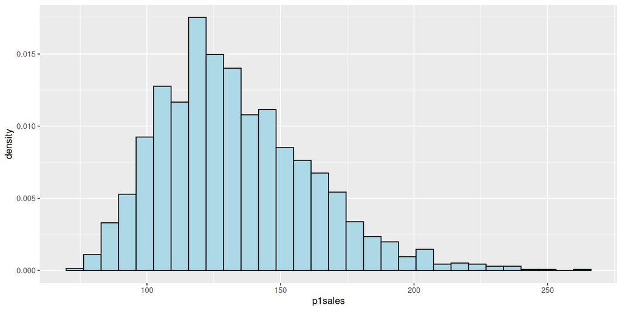

Figure 3: Using `geom_histogram()` to apply a geometry

- **Histograms**
  - the tidyverse way

```r
weekly_store_hist_dens <- weekly_store_hist +
  geom_density(
    aes(x = p1sales),
    bw = 10,
    color = "darkred",
    linetype = "solid",
    linewidth = 1
  )

weekly_store_hist_dens
```

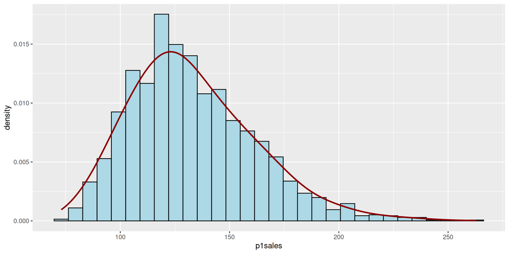

Figure 4: Using `geom_density()` to apply a geometry

- **Histograms**
  - the tidyverse way

```r
weekly_store_hist_dens_scale <- weekly_store_hist_dens +
  scale_x_continuous(
    breaks = seq(
      from = 60,
      to = 300,
      by = 20
    )
  )

weekly_store_hist_dens_scale
```

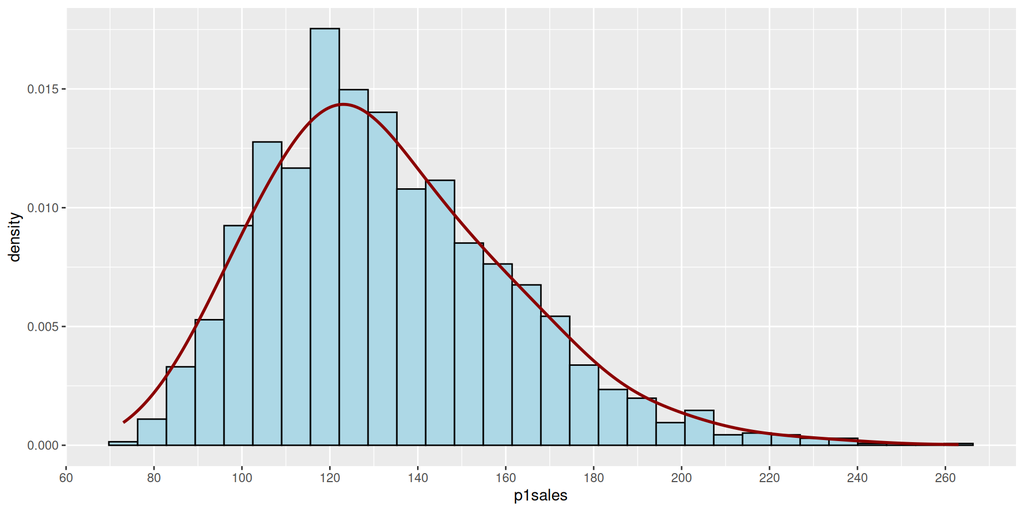

Figure 5: Using `scale_x_continuous()` to modify a scale for the `x` coordinate

- **Histograms**
  - the tidyverse way

```r
weekly_store_hist_dens_scale_labs <- weekly_store_hist_dens_scale +
  labs(
    x = "Product1 Sales (Units)",
    y = "Frequency",
    title = "Product 1 Weekly Sales Frequencies, All Stores"
  )

weekly_store_hist_dens_scale_labs
```

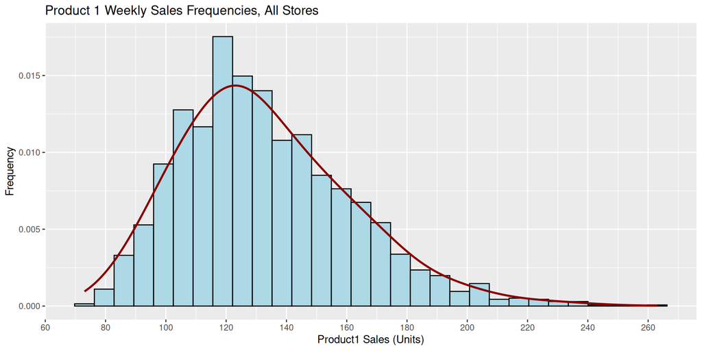

Figure 6: Using `labs()` to modify the labels

- **Boxplots**
  - the tidyverse way

```r
weekly_store |>
  ggplot()
```

- **Boxplots**
  - the tidyverse way

```r
weekly_store_box <- weekly_store |>
  ggplot() +
  geom_boxplot(
    aes(x = p2sales, y = p2prom)
  )

weekly_store_box
```

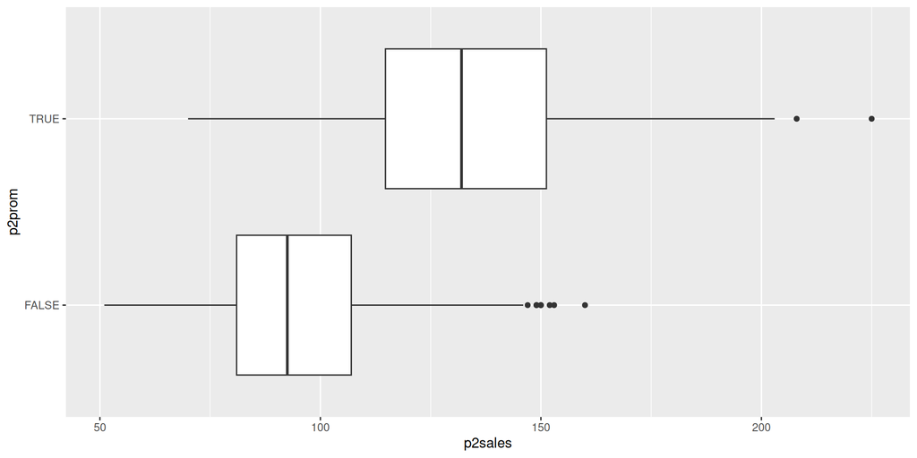

Figure 8: Using `geom_boxplot()` to apply a geometry

- **Boxplots**
  - the tidyverse way

```r
weekly_store_box_scale <- weekly_store_box +
  scale_y_discrete(
    labels = c("No", "Yes")
  )

weekly_store_box_scale
```

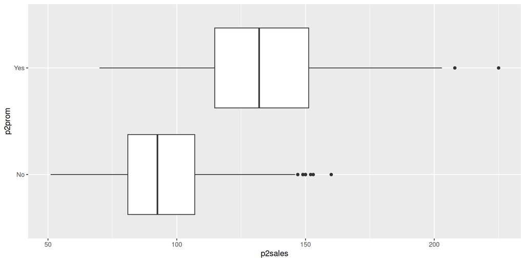

Figure 9: Using `scale_y_discrete()` to modify a scale for the `y` coordinate

- **Boxplots**
  - the tidyverse way

```r
weekly_store_box_scale_labs <- weekly_store_box_scale +
  labs(
    x = "Weekly unit sales",
    y = "P2 promoted in store?",
    title = "Weekly sales of P2 with and without promotion"
  )

weekly_store_box_scale_labs
```

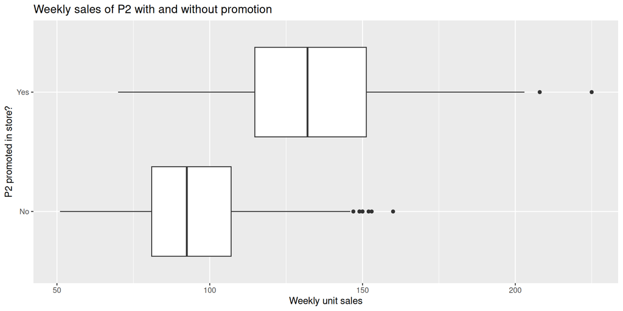

Figure 10: Using `labs()` to modify the labels

# Questions and answers with data

- **In what countries the company sell more units of product 2?**

```r
weekly_store_sales_by_country <- weekly_store |>
  group_by(country)

weekly_store_sales_by_country
```

```
# A tibble: 2,080 × 10
# Groups:   country [7]
   storeNum Year  Week  p1sales p2sales p1price p2price p1prom p2prom country
   <fct>    <ord> <ord>   <dbl>   <dbl>   <dbl>   <dbl> <lgl>  <lgl>  <chr>
 1 101      1     1         127     106    2.29    2.29 FALSE  FALSE  US
 2 101      1     2         137     105    2.49    2.49 FALSE  FALSE  US
 3 101      1     3         156      97    2.99    2.99 TRUE   FALSE  US
 4 101      1     4         117     106    2.99    3.19 FALSE  FALSE  US
 5 101      1     5         138     100    2.49    2.59 FALSE  TRUE   US
 6 101      1     6         115     127    2.79    2.49 FALSE  FALSE  US
 7 101      1     7         116      90    2.99    3.19 FALSE  FALSE  US
 8 101      1     8         106     126    2.99    2.29 FALSE  FALSE  US
 9 101      1     9         116      94    2.29    2.29 FALSE  FALSE  US
10 101      1     10        145      91    2.49    2.99 FALSE  FALSE  US
# ℹ 2,070 more rows
```

- Preparing the data
- **In what countries the company sell more units of product 2?**

```r
weekly_store_sales_by_country <- weekly_store |>
  group_by(country) |>
  summarise(sum_p2sales = sum(p2sales))

weekly_store_sales_by_country
```

```
# A tibble: 7 × 2
  country sum_p2sales
  <chr>         <dbl>
1 AU             9934
2 BR            21362
3 CN            20911
4 DE            52263
5 GB            31264
6 JP            41344
7 US            31248
```

- Preparing the data
- **In what countries the company sell more units of product 2?**

```r
weekly_store_sales_by_country <- weekly_store |>
  group_by(country) |>
  summarise(sum_p2sales = sum(p2sales)) |>
  mutate(
    country = fct_reorder(
      .f = country,
      .x = sum_p2sales
    )
  )

weekly_store_sales_by_country
```

```
# A tibble: 7 × 2
  country sum_p2sales
  <fct>         <dbl>
1 AU             9934
2 BR            21362
3 CN            20911
4 DE            52263
5 GB            31264
6 JP            41344
7 US            31248
```

- Preparing the data
- **In what countries the company sell more units of product 2?**

```r
weekly_store_sales_by_country |>
  ggplot()
```

- Visualizing data

- **In what countries the company sell more units of product 2?**

```r
weekly_store_sales_by_country |>
  ggplot() +
  geom_col(
    aes(x = country, y = sum_p2sales)
  )
```

- Visualizing data

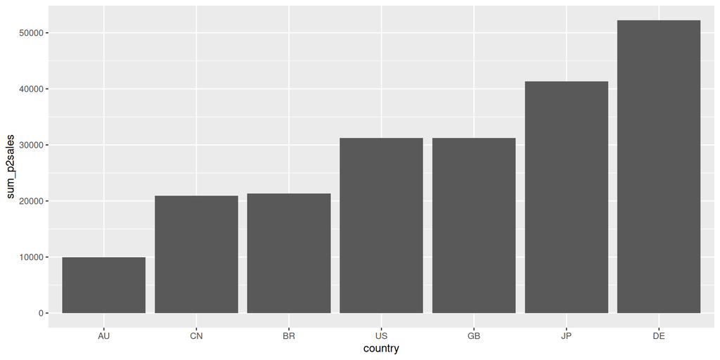

Figure 12: Using `geom_col()` to apply a geometry

- **In what countries the company sell more units of product 2?**

```r
weekly_store_sales_by_country |>
  ggplot() +
  geom_col(
    aes(
      x = country,
      y = sum_p2sales,
      fill = country
    ),
    color = "black",
    show.legend = FALSE
  )
```

- Visualizing data

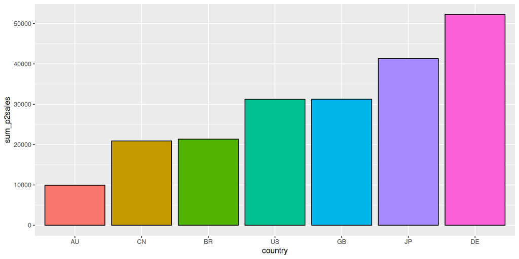

Figure 13: Using `geom_col()` to apply aesthetics and geometry

- **In what countries the company sell more units of product 2?**

```r
weekly_store_sales_by_country |>
  ggplot() +
  geom_col(
    aes(x = country, y = sum_p2sales, fill = country),
    color = "black",
    show.legend = FALSE
  ) +
  scale_x_discrete(
    labels = c(
      "Australia",
      "Japan",
      "Brazil",
      "Britain",
      "Germany",
      "China",
      "United States"
    )
  )
```

- Visualizing data

[figure not shown]

Figure 14: Using `scale_x_discrete()` to modify a scale for the `x` coordinate

- **In what countries the company sell more units of product 2?**

```r
weekly_store_sales_by_country |>
  ggplot() +
  geom_col(
    aes(x = country, y = sum_p2sales, fill = country),
    color = "black",
    show.legend = FALSE
  ) +
  scale_x_discrete(
    labels = c(
      "Australia",
      "Japan",
      "Brazil",
      "Britain",
      "Germany",
      "China",
      "United States"
    )
  ) +
  labs(
    x = NULL,
    y = "Sales (Units)",
    title = "Sales in units per country"
  )
```

- Visualizing data

[figure not shown]

Figure 15: Using `labs()` to modify the labels

# Acknowledgments

- To my family that supports me
- To the taxpayers of Colombia and the [**UMNG students**](https://www.umng.edu.co/estudiante) who pay my salary
- To the [**Business Science**](https://www.business-science.io/) and [**R4DS Online Learning**](https://www.rfordatasci.com/) communities where I learn [**R**](https://www.r-project.org/about.html) and [**$\pi$-thon**](https://www.python.org/about/)
- To the [**R Core Team**](https://www.r-project.org/contributors.html), the creators of [**RStudio IDE**](https://posit.co/products/open-source/rstudio/), [**Quarto**](https://quarto.org/) and the authors and maintainers of the packages [**tidyverse**](https://CRAN.R-project.org/package=tidyverse), [**skimr**](https://CRAN.R-project.org/package=skimr) and [**tinytex**](https://CRAN.R-project.org/package=tinytex) for allowing me to access these tools without paying for a license

# References

Chapman, C., & Feit, E. M. (2019). *R For Marketing Research and Analytics* (2nd ed. 2019). Springer International Publishing : Imprint: Springer. https://doi-org.ezproxy.umng.edu.co/10.1007/978-3-030-14316-9